Importing the required libraries

```python
# IMPORTING LIBRARIES
import pandas as pd # importing pandas
import numpy as np # importing numpy
import matplotlib.pyplot as plt # importing pyplot from matplotlib
import math # importing math library
```

# Data Preparation

## Write a python program to load data into pandas DataFrame.

```python
# reading the csv file and converting it into a DataFrame
saldf = pd.read_csv("DataScienceSalaries.csv")
saldf.head(10)
```

|  | work_year | experience_level | employment_type | job_title | salary | salary_currency | salary_in_usd | employee_residence | remote_ratio | company_location | company_size |
| --- | --- | --- | --- | --- | --- | --- | --- | --- | --- | --- | --- |
| 0 | 2023 | SE | FT | Principal Data Scientist | 80000 | EUR | 85847 | ES | 100 | ES | L |
| 1 | 2023 | MI | CT | ML Engineer | 30000 | USD | 30000 | US | 100 | US | S |
| 2 | 2023 | MI | CT | ML Engineer | 25500 | USD | 25500 | US | 100 | US | S |
| 3 | 2023 | SE | FT | Data Scientist | 175000 | USD | 175000 | CA | 100 | CA | M |
| 4 | 2023 | SE | FT | Data Scientist | 120000 | USD | 120000 | CA | 100 | CA | M |
| 5 | 2023 | SE | FT | Applied Scientist | 222200 | USD | 222200 | US | 0 | US | L |
| 6 | 2023 | SE | FT | Applied Scientist | 136000 | USD | 136000 | US | 0 | US | L |
| 7 | 2023 | SE | FT | Data Scientist | 219000 | USD | 219000 | CA | 0 | CA | M |
| 8 | 2023 | SE | FT | Data Scientist | 141000 | USD | 141000 | CA | 0 | CA | M |
| 9 | 2023 | SE | FT | Data Scientist | 147100 | USD | 147100 | US | 0 | US | M |

## Write a python program to remove unnecessary columns, i.e., salary and salary_currency.

```python
### DATA PREPARATION ###

# removing the 'salary' and 'salary_currency' columns
saldf.drop(columns = ["salary","salary_currency"], inplace=True)
saldf.head(10)
```

|  | work_year | experience_level | employment_type | job_title | salary_in_usd | employee_residence | remote_ratio | company_location | company_size |
| --- | --- | --- | --- | --- | --- | --- | --- | --- | --- |
| 0 | 2023 | SE | FT | Principal Data Scientist | 85847 | ES | 100 | ES | L |
| 1 | 2023 | MI | CT | ML Engineer | 30000 | US | 100 | US | S |
| 2 | 2023 | MI | CT | ML Engineer | 25500 | US | 100 | US | S |
| 3 | 2023 | SE | FT | Data Scientist | 175000 | CA | 100 | CA | M |
| 4 | 2023 | SE | FT | Data Scientist | 120000 | CA | 100 | CA | M |
| 5 | 2023 | SE | FT | Applied Scientist | 222200 | US | 0 | US | L |
| 6 | 2023 | SE | FT | Applied Scientist | 136000 | US | 0 | US | L |
| 7 | 2023 | SE | FT | Data Scientist | 219000 | CA | 0 | CA | M |
| 8 | 2023 | SE | FT | Data Scientist | 141000 | CA | 0 | CA | M |
| 9 | 2023 | SE | FT | Data Scientist | 147100 | US | 0 | US | M |

## Write a python program to remove the NaN missing values from updated DataFrame.

```python
# checking for null values in the dataframe
saldf.isnull().sum()
```

```
work_year             0
experience_level      0
employment_type       0
job_title             0
salary_in_usd         0
employee_residence    0
remote_ratio          0
company_location      0
company_size          0
dtype: int64
```

```python
# removing NaN values
saldf.dropna(inplace=True)
saldf.isnull().sum()
```

```
work_year             0
experience_level      0
employment_type       0
job_title             0
salary_in_usd         0
employee_residence    0
remote_ratio          0
company_location      0
company_size          0
dtype: int64
```

## Write a python program to check for duplicate values in the DataFrame.

```python
# checking for duplicate rows in the DataFrame
duplicated_rows = saldf[saldf.duplicated()]
duplicated_rows.head(10)
```

|  | work_year | experience_level | employment_type | job_title | salary_in_usd | employee_residence | remote_ratio | company_location | company_size |
| --- | --- | --- | --- | --- | --- | --- | --- | --- | --- |
| 115 | 2023 | SE | FT | Data Scientist | 150000 | US | 0 | US | M |
| 123 | 2023 | SE | FT | Analytics Engineer | 289800 | US | 0 | US | M |
| 153 | 2023 | MI | FT | Data Engineer | 100000 | US | 100 | US | M |
| 154 | 2023 | MI | FT | Data Engineer | 70000 | US | 100 | US | M |
| 160 | 2023 | SE | FT | Data Engineer | 115000 | US | 0 | US | M |
| 163 | 2023 | SE | FT | Applied Scientist | 309400 | US | 0 | US | L |
| 164 | 2023 | SE | FT | Applied Scientist | 159100 | US | 0 | US | L |
| 167 | 2023 | MI | FT | Data Engineer | 162500 | US | 0 | US | M |
| 168 | 2023 | MI | FT | Data Engineer | 130000 | US | 0 | US | M |
| 171 | 2023 | SE | FT | Data Engineer | 145000 | US | 0 | US | M |

## Write a python program to see the unique values from all the columns in the DataFrame.

```python
# checking for unique values in all columns of the DataFrame

for col in saldf:
    if (saldf[col].dtype == 'object'):
        print(str(col), '\n', saldf[col].unique(), '\n')
```

```
experience_level
 ['SE' 'MI' 'EN' 'EX']

employment_type
 ['FT' 'CT' 'FL' 'PT']

job_title
 ['Principal Data Scientist' 'ML Engineer' 'Data Scientist'
 'Applied Scientist' 'Data Analyst' 'Data Modeler' 'Research Engineer'
 'Analytics Engineer' 'Business Intelligence Engineer'
 'Machine Learning Engineer' 'Data Strategist' 'Data Engineer'
 'Computer Vision Engineer' 'Data Quality Analyst'
 'Compliance Data Analyst' 'Data Architect'
 'Applied Machine Learning Engineer' 'AI Developer' 'Research Scientist'
 'Data Analytics Manager' 'Business Data Analyst' 'Applied Data Scientist'
 'Staff Data Analyst' 'ETL Engineer' 'Data DevOps Engineer' 'Head of Data'
 'Data Science Manager' 'Data Manager' 'Machine Learning Researcher'
 'Big Data Engineer' 'Data Specialist' 'Lead Data Analyst'
 'BI Data Engineer' 'Director of Data Science'
 'Machine Learning Scientist' 'MLOps Engineer' 'AI Scientist'
 'Autonomous Vehicle Technician' 'Applied Machine Learning Scientist'
 'Lead Data Scientist' 'Cloud Database Engineer' 'Financial Data Analyst'
 'Data Infrastructure Engineer' 'Software Data Engineer' 'AI Programmer'
 'Data Operations Engineer' 'BI Developer' 'Data Science Lead'
 'Deep Learning Researcher' 'BI Analyst' 'Data Science Consultant'
 'Data Analytics Specialist' 'Machine Learning Infrastructure Engineer'
 'BI Data Analyst' 'Head of Data Science' 'Insight Analyst'
 'Deep Learning Engineer' 'Machine Learning Software Engineer'
 'Big Data Architect' 'Product Data Analyst'
 'Computer Vision Software Engineer' 'Azure Data Engineer'
 'Marketing Data Engineer' 'Data Analytics Lead' 'Data Lead'
 'Data Science Engineer' 'Machine Learning Research Engineer'
 'NLP Engineer' 'Manager Data Management' 'Machine Learning Developer'
 '3D Computer Vision Researcher' 'Principal Machine Learning Engineer'
 'Data Analytics Engineer' 'Data Analytics Consultant'
 'Data Management Specialist' 'Data Science Tech Lead'
 'Data Scientist Lead' 'Cloud Data Engineer' 'Data Operations Analyst'
 'Marketing Data Analyst' 'Power BI Developer' 'Product Data Scientist'
 'Principal Data Architect' 'Machine Learning Manager'
 'Lead Machine Learning Engineer' 'ETL Developer' 'Cloud Data Architect'
 'Lead Data Engineer' 'Head of Machine Learning' 'Principal Data Analyst'
 'Principal Data Engineer' 'Staff Data Scientist' 'Finance Data Analyst']

employee_residence
 ['ES' 'US' 'CA' 'DE' 'GB' 'NG' 'IN' 'HK' 'PT' 'NL' 'CH' 'CF' 'FR' 'AU'
 'FI' 'UA' 'IE' 'IL' 'GH' 'AT' 'CO' 'SG' 'SE' 'SI' 'MX' 'UZ' 'BR' 'TH'
 'HR' 'PL' 'KW' 'VN' 'CY' 'AR' 'AM' 'BA' 'KE' 'GR' 'MK' 'LV' 'RO' 'PK'
 'IT' 'MA' 'LT' 'BE' 'AS' 'IR' 'HU' 'SK' 'CN' 'CZ' 'CR' 'TR' 'CL' 'PR'
 'DK' 'BO' 'PH' 'DO' 'EG' 'ID' 'AE' 'MY' 'JP' 'EE' 'HN' 'TN' 'RU' 'DZ'
 'IQ' 'BG' 'JE' 'RS' 'NZ' 'MD' 'LU' 'MT']

company_location
 ['ES' 'US' 'CA' 'DE' 'GB' 'NG' 'IN' 'HK' 'NL' 'CH' 'CF' 'FR' 'FI' 'UA'
 'IE' 'IL' 'GH' 'CO' 'SG' 'AU' 'SE' 'SI' 'MX' 'BR' 'PT' 'RU' 'TH' 'HR'
 'VN' 'EE' 'AM' 'BA' 'KE' 'GR' 'MK' 'LV' 'RO' 'PK' 'IT' 'MA' 'PL' 'AL'
 'AR' 'LT' 'AS' 'CR' 'IR' 'BS' 'HU' 'AT' 'SK' 'CZ' 'TR' 'PR' 'DK' 'BO'
 'PH' 'BE' 'ID' 'EG' 'AE' 'LU' 'MY' 'HN' 'JP' 'DZ' 'IQ' 'CN' 'NZ' 'CL'
 'MD' 'MT']

company_size
 ['L' 'S' 'M']
```

## Rename the experience level columns below.

- SE – Senior Level/Expert
- MI – Medium Level/Intermediate
- EN – Entry Level
- EX – Executive Level

```python
# renaming the three experience level values
saldf["experience_level"] = saldf["experience_level"].replace(["SE","MI","EN","EX"], ["Senior Level/Expert","Medium Level/Intermediate","Entry Level","Executive Level"])
saldf.head(10)
```

|  | work_year | experience_level | employment_type | job_title | salary_in_usd | employee_residence | remote_ratio | company_location | company_size |
| --- | --- | --- | --- | --- | --- | --- | --- | --- | --- |
| 0 | 2023 | Senior Level/Expert | FT | Principal Data Scientist | 85847 | ES | 100 | ES | L |
| 1 | 2023 | Medium Level/Intermediate | CT | ML Engineer | 30000 | US | 100 | US | S |
| 2 | 2023 | Medium Level/Intermediate | CT | ML Engineer | 25500 | US | 100 | US | S |
| 3 | 2023 | Senior Level/Expert | FT | Data Scientist | 175000 | CA | 100 | CA | M |
| 4 | 2023 | Senior Level/Expert | FT | Data Scientist | 120000 | CA | 100 | CA | M |
| 5 | 2023 | Senior Level/Expert | FT | Applied Scientist | 222200 | US | 0 | US | L |
| 6 | 2023 | Senior Level/Expert | FT | Applied Scientist | 136000 | US | 0 | US | L |
| 7 | 2023 | Senior Level/Expert | FT | Data Scientist | 219000 | CA | 0 | CA | M |
| 8 | 2023 | Senior Level/Expert | FT | Data Scientist | 141000 | CA | 0 | CA | M |
| 9 | 2023 | Senior Level/Expert | FT | Data Scientist | 147100 | US | 0 | US | M |

# Data Analysis

## Write a Python program to show summary statistics of sum, mean, standard deviation, skewness, and kurtosis of any chosen variable.

### Utility Functions

#### Input column verification function

Defining a function to verify that the input column exists in the DataFrame and is numeric

```python
### DATA ANALYSIS ###

### UTILITY FUNCTIONS ###

# defining a function to verify that the input column exists in the DataFrame and is numeric

def verify_input_column(input_stmt):
    """
    Purpose:
        Checks if the user-input column exists and is of int64 datatype

    Parameters:
        input string

    Returns:
        column
    """

    numeric_cols = [col for col in saldf.columns if saldf[col].dtype=='int64'] # list of all numeric columns of the dataframe
    input_stmt += " from among these ones:\n" + ", ".join(numeric_cols) + "\n\n" # displaying the numeric columns with the input statement
    error_msg = "\nInvalid input\n" # error message

    while True:
        col = input(input_stmt) # taking input from the user

        if(col in numeric_cols): break # breaking the loop if the entered column exists and is numeric
        else: print(error_msg) # printing error message if column does not exist

    return col # returning the verified column
```

Testing the above function

```python
verify_input_column("Enter a column")
```

```
Enter a column from among these ones:
work_year, salary_in_usd, remote_ratio

salary

Invalid input

Enter a column from among these ones:
work_year, salary_in_usd, remote_ratio

job_title

Invalid input

Enter a column from among these ones:
work_year, salary_in_usd, remote_ratio

salary_in_usd
```

```
'salary_in_usd'
```

#### Median functions

Defining functions to calculate the median of all values in a column

```python
# defining functions to calculate the median of all values in a column

def calc_arg_median(col):
    """
    Purpose:
        Calculates median value of the argument numeric column of a DataFrame

    Parameters:
        a numeric column

    Returns:
        median
    """

    sorted_col = saldf[col].sort_values() # sorting the values of col in ascending order
    median_index = 0 # index of the median value in col

    # condition to check if col has an even or odd number of values
    if len(sorted_col)%2 == 0: # if col has an even number of values
        median_index = len(sorted_col)//2 # index of the median value is
                                        # half of the number of values
    else: # if col has an odd number of values
        median_index = (len(sorted_col) + 1)//2 # index of the median value is
                                            # half of one more than the number of values

    # median value of col
    median = sorted_col.iloc[median_index - 1] # subtracting 1 since indices start from 0
    return median # returning the median value
```

```python
def calc_median(): # ENTRY FUNCTION
    """
    Purpose:
        Calculates median value of a user-entered numeric column of a DataFrame

    Parameters:
        none

    Returns:
        median
    """

    # taking input column and verifying that it exists and is numeric
    col = verify_input_column("Enter a column")
    median = calc_arg_median(col) # calculating median value
    return median # returns the median value
```

Testing the above functions

```python
col = 'salary_in_usd'

print("Median:", calc_median()) # input-taking function
print("Median:", calc_arg_median(col)) # argument-taking function
print("Median:", saldf[col].median()) # built-in function
```

```
Enter a column from among these ones:
work_year, salary_in_usd, remote_ratio

salary_in_usd
Median: 135000
Median: 135000
Median: 135000.0
```

### Sum functions

Defining functions to calculate the sum of all values in a column

```python
# defining functions to calculate the sum of all values in a column

def calc_arg_sum(col):
    """
    Purpose:
        Calculates sum of all values of the argument numeric column of a DataFrame

    Parameters:
        a numeric column

    Returns:
        sum
    """

    sum = 0 # summation of all values of col
    for values in saldf[col]:
        sum += values # sum of all values of col
    return sum # returning the sum
```

```python
def calc_sum():  # ENTRY FUNCTION
    """
    Purpose:
        Calculates sum of all values of a user-entered numeric column of a DataFrame

    Parameters:
        none

    Returns:
        sum
    """

    # taking input column and verifying that it exists and is numeric
    col = verify_input_column("Enter a column")
    sum = calc_arg_sum(col) # calculating the sum
    return sum # returning the sum
```

Testing the above functions

```python
col = 'salary_in_usd'

print("Sum:", calc_sum()) # input-taking function
print("Sum:", calc_arg_sum(col)) # argument-taking function
print("Sum:", saldf[col].sum()) # built-in function
```

```
Enter a column from among these ones:
work_year, salary_in_usd, remote_ratio

salary_in_usd
Sum: 516576814
Sum: 516576814
Sum: 516576814
```

### Mean Functions

Defining functions to calculate the mean of all values in a column

```python
# defining functions to calculate the mean of all values in a column

def calc_arg_mean(col):
    """
    Purpose:
        Calculates mean value of the argument numeric column of a DataFrame

    Parameters:
        a numeric column

    Returns:
        mean
    """

    col_sum = calc_arg_sum(col) # sum of all values of col
    mean = col_sum/len(saldf[col]) # mean value of col
    return mean # returning the mean value
```

```python
def calc_mean():  # ENTRY FUNCTION
    """
    Purpose:
        Calculates mean value of a user-entered numeric column of a DataFrame

    Parameters:
        none

    Returns:
        mean
    """

    # taking input column and verifying that it exists and is numeric
    col = verify_input_column("Enter a column")
    mean = calc_arg_mean(col) # calculating mean value
    return mean # returning the mean value
```

Testing the above functions

```python
col = 'salary_in_usd'

print("Mean:", calc_mean()) # input-taking function
print("Mean:", calc_arg_mean(col)) # argument-taking function
print("Mean:", saldf[col].mean()) # built-in function
```

```
Enter a column from among these ones:
work_year, salary_in_usd, remote_ratio

salary_in_usd
Mean: 137570.38988015978
Mean: 137570.38988015978
Mean: 137570.38988015978
```

### Standard Deviation Functions

Defining functions to calculate the standard deviation of all values in a column

```python
# defining functions to calculate the standard deviation of all values in a column

def calc_arg_stdev(col):
    """
    Purpose:
        Calculates standard deviation of the argument numeric column of a DataFrame

    Parameters:
        a numeric column

    Returns:
        standard deviation
    """

    mean = calc_arg_mean(col) # mean value of col
    sum_of_squared_diffs = 0 # summation of (x - X)^2,
                             # where x is each value of col,
                             # and X is the mean value of col

    # iteratively adding (x - X)^2
    for value in saldf[col]:
        sum_of_squared_diffs += (value - mean)**2

    var = sum_of_squared_diffs/(len(saldf[col])-1) # variance value of col
    stdev = (var)**0.5 # standard deviation of col
    return stdev # returning the stnadard deviation
```

```python
def calc_stdev(): # ENTRY FUNCTION
    """
    Purpose:
        Calculates standard deviation of a user-entered numeric column of a DataFrame

    Parameters:
        none

    Returns:
        standard deviation
    """

    # taking input column and verifying that it exists and is numeric
    col = verify_input_column("Enter a column")
    stdev = calc_arg_stdev(col) # calculating standard deviation value
    return stdev # returns the standard deviation value
```

Testing the above functions

```python
col = 'salary_in_usd'

print("Standard Deviation:", calc_stdev()) # input-taking function
print("Standard Deviation:", calc_arg_stdev(col)) # argument-taking function
print("Standard Deviation:", saldf[col].std()) # built-in function
```

```
Enter a column from among these ones:
work_year, salary_in_usd, remote_ratio

salary_in_usd
Standard Deviation: 63055.625278224084
Standard Deviation: 63055.625278224084
Standard Deviation: 63055.6252782241
```

### Skewness Functions

Defining functions to calculate the skewness of all values in a column

```python
# defining functions to calculate the skewness of all values in a column

def calc_arg_skew(col):
    """
    Purpose:
        Calculates skewness value of the argument numeric column of a DataFrame

    Parameters:
        a numeric column

    Returns:
        skewness
    """

    mean = calc_arg_mean(col) # mean value of col
    median = calc_arg_median(col) # median value of col
    std = calc_arg_stdev(col) # standard deviation of col
    sum_of_cubed_diffs = 0 # summation of (x - X)^3,
                           # where x is each value of col
                           # and X is the mean value of col

    # iteratively adding (x - X)^3 together
    for value in saldf[col]:
        sum_of_cubed_diffs += (value - mean)**3

    denom = (len(saldf[col]) - 1) * (std**3) # denominator of the skewness formula
    skewness = sum_of_cubed_diffs/denom # skweness value of col
    return skewness # returning the skewness value
```

```python
def calc_skew(): # ENTRY FUNCTION
    """
    Purpose:
        Calculates skewness value of a user-entered numeric column of a DataFrame

    Parameters:
        none

    Returns:
        skewness
    """

    # taking input column and verifying that it exists and is numeric
    col = verify_input_column("Enter a column")
    stdev = calc_arg_skew(col) # calculating skewness value
    return stdev # returns the skewness value
```

Testing the above functions

```python
col = 'salary_in_usd'

print("Skewness:", calc_skew()) # input-taking function
print("Skewness:", calc_arg_skew(col)) # argument-taking function
print("Skewness:", saldf[col].skew()) # built-in function
```

```
Enter a column from among these ones:
work_year, salary_in_usd, remote_ratio

salary_in_usd
Skewness: 0.5361154662823615
Skewness: 0.5361154662823615
Skewness: 0.5364011659712974
```

### Kurtosis Functions

Defining functions to calculate the kurtosis of all values in a column

```python
# defining functions to calculate the kurtosis of all values in a column

def calc_arg_kurt(col):
    """
    Purpose:
        Calculates kurtosis value of the argument numeric column of a DataFrame

    Parameters:
        a numeric column

    Returns:
        kurtosis
    """

    std = calc_arg_stdev(col) # standard deviation of col
    mean = calc_arg_mean(col) # mean value of col
    sum_of_4th_powers = 0 # summation of (x - X)^4,
                          # where x is each value of col1
                          # and X is the mean value of col1

    # iteratively adding (x - X)^4
    for value in saldf[col]:
        sum_of_4th_powers += (value - mean)**4

    fourth_moment = sum_of_4th_powers/len(saldf[col]) # fourth moment value of col
    kurt = fourth_moment/(std**4) # kurtosis value of col
    return kurt-3 # returning the kurtosis value
```

```python
def calc_kurt(): # ENTRY FUNCTION
    """
    Purpose:
        Calculates kurtosis value of a user-entered numeric column of a DataFrame

    Parameters:
        none

    Returns:
        kurtosis
    """

    # taking input column and verifying that it exists and is numeric
    col = verify_input_column("Enter a column")
    kurt = calc_arg_kurt(col) # calculating kurtosis value
    return kurt # returns the kurtosis value
```

Testing the above functions

```python
col = 'salary_in_usd'

print("Kurtosis:", calc_kurt()) # input-taking function
print("Kurtosis:", calc_arg_kurt(col)) # argument-taking function
print("Kurtosis:", saldf[col].kurt()) # built-in function
```

```
Enter a column from among these ones:
work_year, salary_in_usd, remote_ratio

salary_in_usd
Kurtosis: 0.8292585346115979
Kurtosis: 0.8292585346115979
Kurtosis: 0.8340064594833612
```

## Write a Python program to calculate and show correlation of all variables.

### Correlation Functions

Defining functions to find the correlation between two numeric columns

```python
# defining functions to find the correlation between two numeric columns

def calc_arg_corr(col1, col2):
    """
    Purpose:
        Calculates correlation value of the two argument numeric columns of a DataFrame

    Parameters:
        two numeric columns

    Returns:
        correlation
    """

    col1_mean = calc_arg_mean(col1) # mean value of col1
    col2_mean = calc_arg_mean(col2) # mean value of col2

    col1_stdev = calc_arg_stdev(col1) # standard deviation of col1
    col2_stdev = calc_arg_stdev(col2) # standard deviation of col2

    sum_of_products = 0 # summation of (x - X) * (y - Y),
                        # where x, y = each value of col1, col2 respectively,
                        # and X, Y are the mean values of col1, col2 respectively

    # iteratively adding (x - X) * (y - Y)
    for i in range(len(saldf[col1])):
        sum_of_products += (saldf[col1].iloc[i] - col1_mean) * (saldf[col2].iloc[i] - col2_mean)

    covar = sum_of_products/(len(saldf[col1]) - 1) # covariance between col1 and col2
    corr = covar/(col1_stdev * col2_stdev) # correlation between col1 and col2
    return corr # returning the correlation value
```

```python
def calc_corr(): # ENTRY FUNCTION
    """
    Purpose:
        Calculates correlation value of two user-entered numeric columns of a DataFrame

    Parameters:
        none

    Returns:
        correlation
    """

    # taking input column and verifying that it exists and is numeric
    col1 = verify_input_column("Enter the first column")
    col2 = verify_input_column("Enter the second column")
    corr = calc_arg_corr(col1, col2) # calculating correlation value
    return corr # returns the correlation value
```

Testing the above functions

```python
col1 = 'salary_in_usd'
col2 = 'remote_ratio'

print("Correlation:", calc_corr()) # input-taking function
print("Correlation:", calc_arg_corr(col1, col2)) # argument-taking function
print("Correlation:", saldf[col1].corr(saldf[col2])) # built-in function
```

```
Enter the first column from among these ones:
work_year, salary_in_usd, remote_ratio

salary_in_usd
Enter the second column from among these ones:
work_year, salary_in_usd, remote_ratio

remote_ratio
Correlation: -0.06417098519057539
Correlation: -0.06417098519057539
Correlation: -0.06417098519057558
```

# Data Exploration

## Write a python program to find out the top 15 jobs.

```python
# finding out the top 15 jobs
top_jobs = saldf['job_title'].value_counts().head(15).sort_values()
top_jobs
```

```
job_title
Data Analytics Manager          22
Data Science Consultant         24
Machine Learning Scientist      26
Data Manager                    29
ML Engineer                     34
Research Engineer               37
Data Science Manager            58
Applied Scientist               58
Research Scientist              82
Data Architect                 101
Analytics Engineer             103
Machine Learning Engineer      289
Data Analyst                   612
Data Scientist                 840
Data Engineer                 1040
Name: count, dtype: int64
```

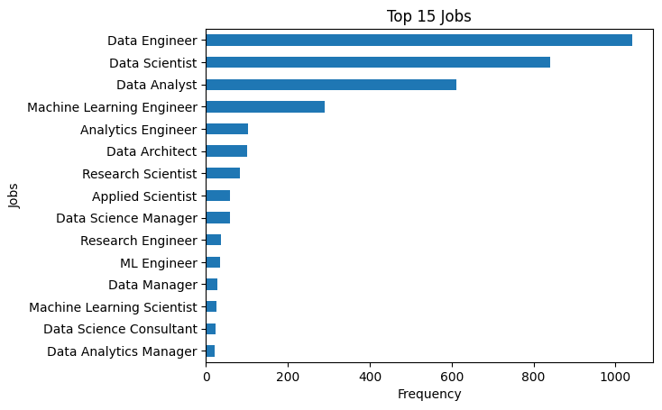

```python
top_jobs.plot(kind = "barh")
plt.ylabel("Jobs")
plt.xlabel("Frequency")
plt.title("Top 15 Jobs")
```

## Which job has the highest salaries? Illustrate with bar graph.

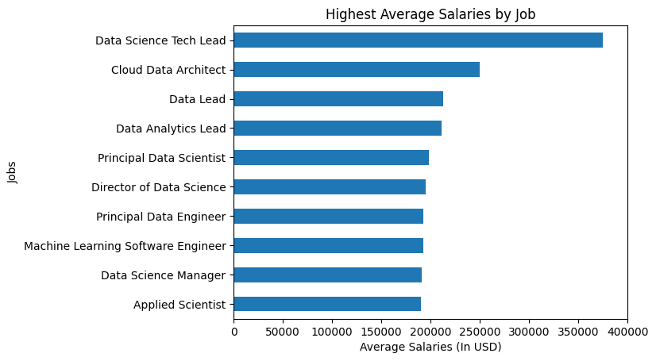

```python
# finding the job with the highest salaries
job_sals = saldf.groupby("job_title")["salary_in_usd"].mean().sort_values(ascending=False).head(10).sort_values()
job_sals.plot(kind="barh")
plt.xlabel("Average Salaries (In USD)")
plt.ylabel("Jobs")
plt.xlim(0,400000)
plt.title("Highest Average Salaries by Job")
```

## Write a python program to find out salaries based on experience level. Illustrate it through bar graph.

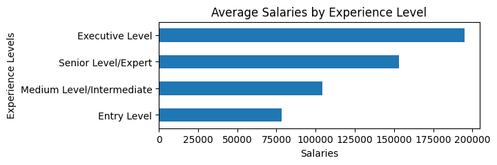

```python
# finding out the salaries based on the experience levels
explvl_sals = saldf.groupby(saldf["experience_level"])["salary_in_usd"].mean().sort_values(ascending=False).head(10).sort_values()
plt.figure(figsize = (6,2))
explvl_sals.plot(kind="barh")
plt.ylabel("Experience Levels")
plt.xlabel("Salaries")
plt.title("Average Salaries by Experience Level")
```

## Write a Python program to show histogram and box plot of any chosen different variables. Use proper labels in the graph.

### Histogram

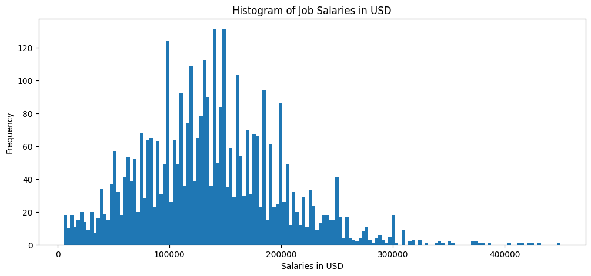

```python
# showing the histogram of the values of a column
plt.figure(figsize=(12,5))
saldf["salary_in_usd"].plot(kind = "hist", bins = 150)
plt.xlabel("Salaries in USD")
plt.title("Histogram of Job Salaries in USD")
```

### Boxplot

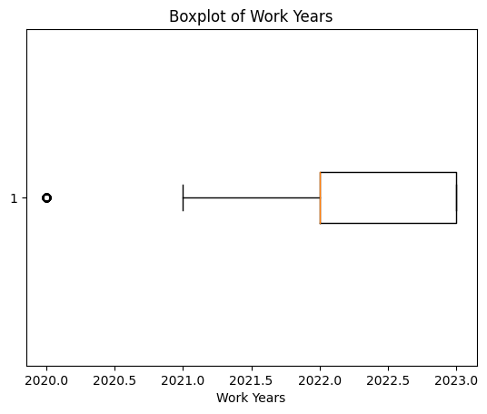

```python
# showing the boxplot of the values of a column
workyears = saldf["work_year"]
plt.boxplot(workyears, vert = False)
plt.xlabel("Work Years")
plt.title("Boxplot of Work Years")
```